# Análisis discriminante

Melina Schamberger

1/7/2022

## Problema de análisis

Este análisis se centra en el **comportamiento de los clientes de telecomunicaciones que tienen más probabilidades de abandonar la plataforma**. El objetivo radica en descubrir el comportamiento más sorprendente de los clientes a través de EDA y luego usar algunas de las técnicas de análisis predictivo para determinar los clientes que tienen más probabilidades de abandonar.

## Sobre los datos

El dataset comprende información sobre:

- Clientes que se fueron en el último mes: la columna se llama **Renuncia**
- Servicios a los que se ha suscrito cada cliente: teléfono, varias líneas, Internet, seguridad en línea, respaldo en línea, protección de dispositivos, soporte técnico y transmisión de TV y películas
- Información de la cuenta del cliente: cuánto tiempo ha sido cliente, contrato, método de pago, facturación electrónica, cargos mensuales y cargos totales.
- Información demográfica sobre los clientes: sexo, rango de edad y si tienen socios y dependientes

## Análisis descriptivo

Se muestran a continuación las primeras seis filas del conjunto de datos:

| customerID | gender | SeniorCitizen | Partner | Dependents | tenure | PhoneService | MultipleLines | InternetService | OnlineSecurity | OnlineBackup | DeviceProtection | TechSupport | StreamingTV | StreamingMovies | Contract | PaperlessBilling | PaymentMethod | MonthlyCharges | TotalCharges | Churn |
| --- | --- | --- | --- | --- | --- | --- | --- | --- | --- | --- | --- | --- | --- | --- | --- | --- | --- | --- | --- | --- |
| 7590-VHVEG | Female | 0 | Yes | No | 1 | No | No phone service | DSL | No | Yes | No | No | No | No | Month-to-month | Yes | Electronic check | 29.85 | 29.85 | No |
| 5575-GNVDE | Male | 0 | No | No | 34 | Yes | No | DSL | Yes | No | Yes | No | No | No | One year | No | Mailed check | 56.95 | 1889.50 | No |
| 3668-QPYBK | Male | 0 | No | No | 2 | Yes | No | DSL | Yes | Yes | No | No | No | No | Month-to-month | Yes | Mailed check | 53.85 | 108.15 | Yes |
| 7795-CFOCW | Male | 0 | No | No | 45 | No | No phone service | DSL | Yes | No | Yes | Yes | No | No | One year | No | Bank transfer (automatic) | 42.30 | 1840.75 | No |
| 9237-HQITU | Female | 0 | No | No | 2 | Yes | No | Fiber optic | No | No | No | No | No | No | Month-to-month | Yes | Electronic check | 70.70 | 151.65 | Yes |
| 9305-CDSKC | Female | 0 | No | No | 8 | Yes | Yes | Fiber optic | No | No | Yes | No | Yes | Yes | Month-to-month | Yes | Electronic check | 99.65 | 820.50 | Yes |

Hay 7043 filas de datos para 21 variables de clientes de telecomunicaciones.

### Limpieza del dataset

Se verifica la existencia de missing cases en las distintas variables:

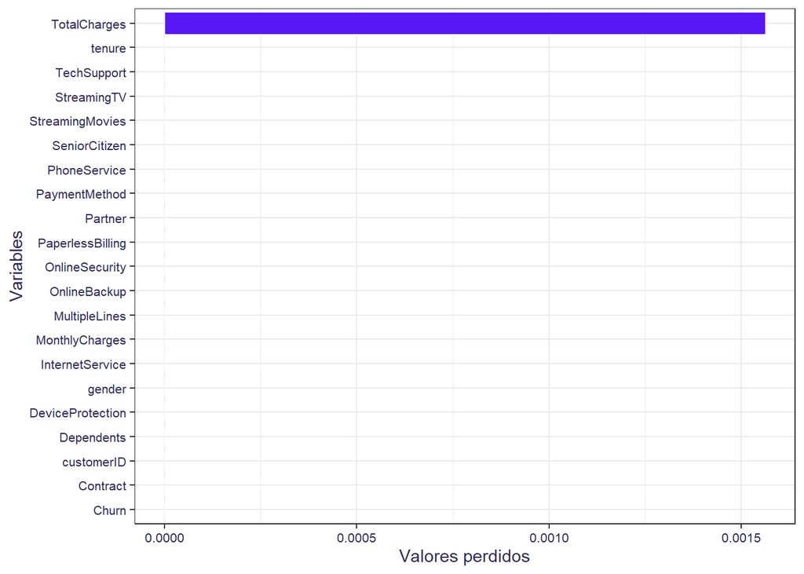

```r
options(repr.plot.width = 6, repr.plot.height = 4)
missing_data <- telco %>% summarise_all(funs(sum(is.na(.))/n()))
missing_data <- gather(missing_data, key = "variables", value = "percent_missing")

#Gráfico
ggplot(missing_data, aes(x = reorder(variables, percent_missing), y = percent_missing)) +
  geom_bar(stat = "identity", fill = "#5817F5", aes(color = I('white')), size = 0.3)+
  xlab('Variables')+
  ylab('Valores perdidos') +
  coord_flip()+
  theme_bw() +
  theme(plot.title = element_text(size=12, face = "bold.italic", color = "#2e2959"),
                          axis.text.y = element_text(size = 8, color = "#2e2959"),
                          axis.text.x = element_text(size = 8, color = "#2e2959"),
                          axis.title.x = element_text(color = "#2e2959"),
                          axis.title.y = element_text(color = "#2e2959"),
                          plot.caption = element_text(color = "#2e2959"),
                          legend.text = element_text(color = "#2e2959"),
                          legend.title = element_text(color = "#2e2959"),
                          plot.subtitle = element_text(color = "#2e2959"))
```

Se encuentra que en la variable TotalCharges existen filas sin casos, por lo que se suprimen dichas observaciones.

```r
telco <- telco[complete.cases(telco),]
```

```r
telco$SeniorCitizen <- as.factor(ifelse(telco$SeniorCitizen==1, 'YES', 'NO'))
```

Para hacer el modelo dicriminante, se usarán solo **variables cuantitativas (tenure, MonthlyCharges, TotalCharges)** como **variables independientes** y variable **“churn (renuncia)” como variable dependiente**.

```r
telco_reducido <- subset(telco, select = c(tenure, MonthlyCharges, TotalCharges, Churn))
```

Para evaluar los resultados, se divide el conjunto de datos en conjunto de entrenamiento y conjunto de prueba:

```r
set.seed(100)
test.index <- sample(1:nrow(telco_reducido), 1000)

#Conjunto de entrenamiento
training_set <- telco_reducido[-test.index,]

#conjunto de prueba
test_set <- telco_reducido[test.index,]
```

Se realizan modificaciones sobre el conjunto de datos de entrenamiento:

```r
training_set_shapiro <- training_set

#Se modifica la variable dependiente (VD)
training_set_shapiro$Renuncia <- ifelse(training_set_shapiro$Churn=="Yes", "Renuncia", "No Renuncia")

#Se suprime la VD en su formato anterior
training_set_shapiro <- subset( training_set_shapiro, select = -Churn )

#Se toma una muestra
training_set_shapiro <- sample_n(training_set_shapiro, 1500)

kable_styling(kable(head(training_set_shapiro)))
```

| tenure | MonthlyCharges | TotalCharges | Renuncia |
| --- | --- | --- | --- |
| 52 | 89.45 | 4577.75 | No Renuncia |
| 15 | 19.75 | 311.60 | No Renuncia |
| 11 | 82.90 | 880.05 | No Renuncia |
| 15 | 80.20 | 1217.25 | Renuncia |
| 7 | 69.55 | 521.35 | No Renuncia |
| 59 | 96.65 | 5580.80 | No Renuncia |

También se modifica la variable dependiente para volverla factorial:

```r
training_set_shapiro$Renuncia <- as.factor(training_set_shapiro$Renuncia)
class(training_set_shapiro$Renuncia)
```

```
## [1] "factor"
```

### Distribución de variables

Habiendo preparado los datasets, se procede a indagar la distribución en cada variable:

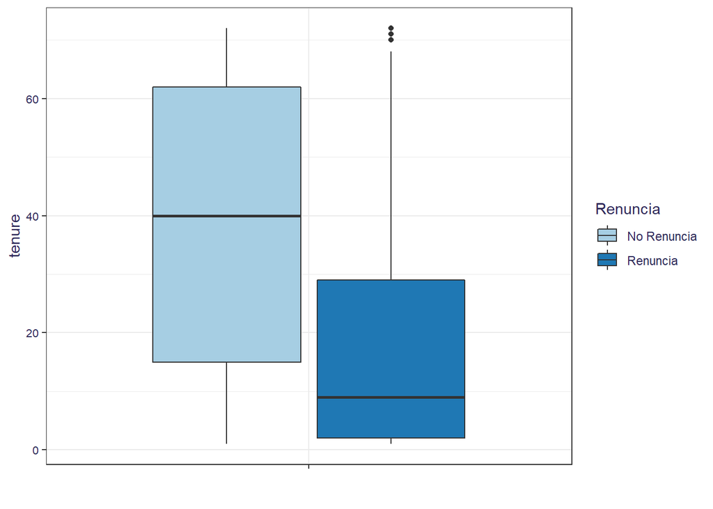

```r
options(repr.plot.width =6, repr.plot.height = 2)
#Gráfico
ggplot(training_set_shapiro, aes(y= tenure, x = "", fill = Renuncia)) +
geom_boxplot()+
theme_bw()+
xlab(" ")+
  theme(plot.title = element_text(size=12, face = "bold.italic", color = "#2e2959"),
                          axis.text.y = element_text(size = 8, color = "#2e2959"),
                          axis.text.x = element_text(size = 8, color = "#2e2959"),
                          axis.title.x = element_text(color = "#2e2959"),
                          axis.title.y = element_text(color = "#2e2959"),
                          plot.caption = element_text(color = "#2e2959"),
                          legend.text = element_text(color = "#2e2959"),
                          legend.title = element_text(color = "#2e2959"),
                          plot.subtitle = element_text(color = "#2e2959")) +
  scale_fill_brewer("Renuncia", palette = "Paired")
```

Se observa que la mediana de la antiguedad es mayor en el caso de los clientes que no han renunciado al servicio.

#### **Cargas mensuales**

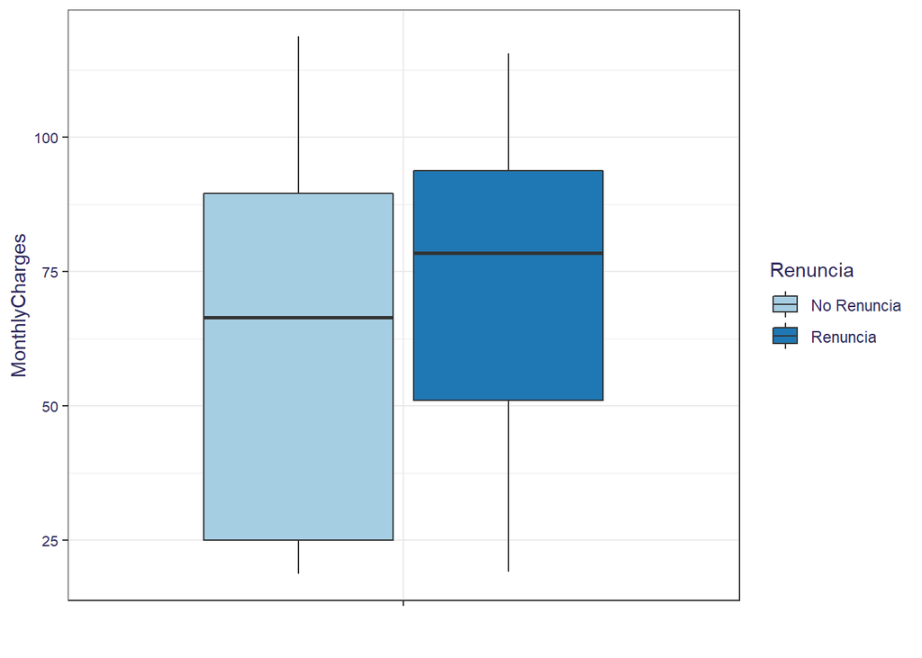

```r
ggplot(training_set_shapiro, aes(y= MonthlyCharges, x = "", fill = Renuncia)) +
geom_boxplot()+
theme_bw()+
xlab(" ")+
  theme(plot.title = element_text(size=12, face = "bold.italic", color = "#2e2959"),
                          axis.text.y = element_text(size = 8, color = "#2e2959"),
                          axis.text.x = element_text(size = 8, color = "#2e2959"),
                          axis.title.x = element_text(color = "#2e2959"),
                          axis.title.y = element_text(color = "#2e2959"),
                          plot.caption = element_text(color = "#2e2959"),
                          legend.text = element_text(color = "#2e2959"),
                          legend.title = element_text(color = "#2e2959"),
                          plot.subtitle = element_text(color = "#2e2959")) +
  scale_fill_brewer("Renuncia", palette = "Paired")
```

Los *clientes que abandonaron el servicio tienen una mediana más alta en la carga de servicios mensuales*.

#### **Cargas totales**

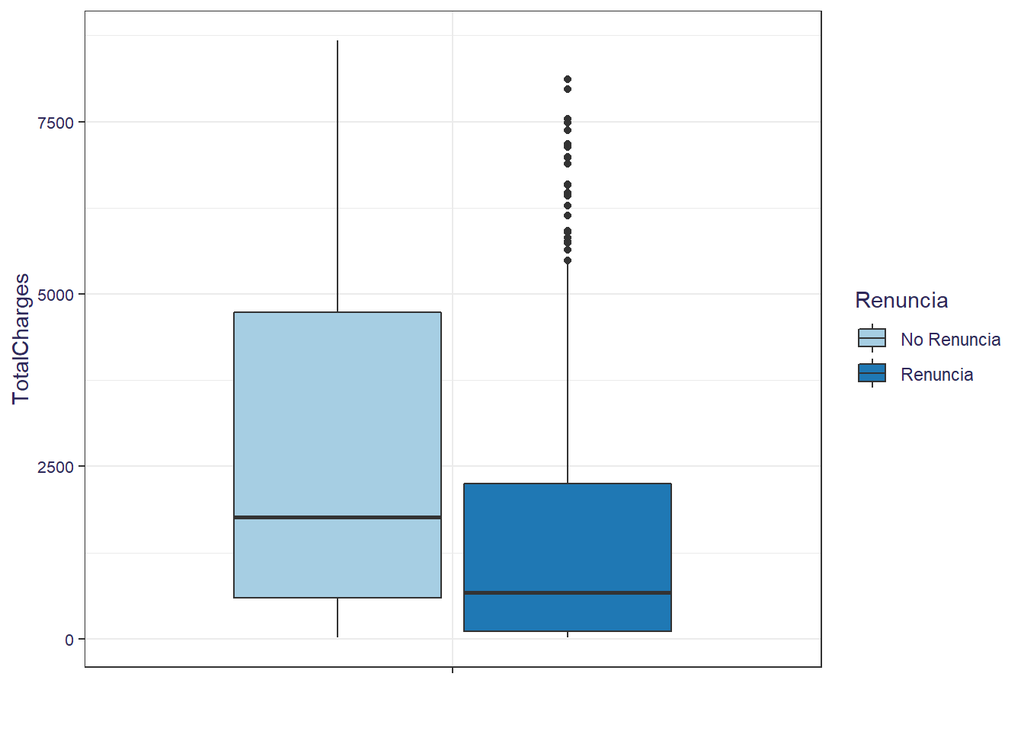

```r
ggplot(training_set_shapiro, aes(y= TotalCharges, x = "", fill = Renuncia)) +
geom_boxplot()+
theme_bw()+
xlab(" ")+
  theme(plot.title = element_text(size=12, face = "bold.italic", color = "#2e2959"),
                          axis.text.y = element_text(size = 8, color = "#2e2959"),
                          axis.text.x = element_text(size = 8, color = "#2e2959"),
                          axis.title.x = element_text(color = "#2e2959"),
                          axis.title.y = element_text(color = "#2e2959"),
                          plot.caption = element_text(color = "#2e2959"),
                          legend.text = element_text(color = "#2e2959"),
                          legend.title = element_text(color = "#2e2959"),
                          plot.subtitle = element_text(color = "#2e2959")) +
  scale_fill_brewer("Renuncia", palette = "Paired")
```

Los *clientes que renunciaron al servicio posee una mediana menor en sus cargas totales*, respecto a los que no renunciaron.

Luego, se realiza una representación mediante histogramas de cada variable para cada categoría de la VD:

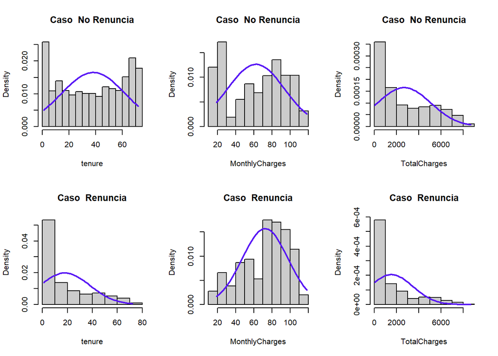

```r
par(mfcol = c(2, 3))
for (k in 1:3) {
  j0 <- names(training_set_shapiro)[k]
  #br0 <- seq(min(datos[, k]), max(datos[, k]), le = 11)
  x0 <- seq(min(training_set_shapiro[, k]), max(training_set_shapiro[, k]), le = 50)
  for (i in 1:2) {
    i0 <- levels(training_set_shapiro$Renuncia)[i]
    x <- training_set_shapiro[training_set_shapiro$Renuncia == i0, j0]
    hist(x, proba = T, col = grey(0.8), main = paste("Caso ", i0),
    xlab = j0)
    lines(x0, dnorm(x0, mean(x), sd(x)), col = "#5817F5", lwd = 2)
  }
}
```

Se muestra lo equivalente mediante otra visualización:

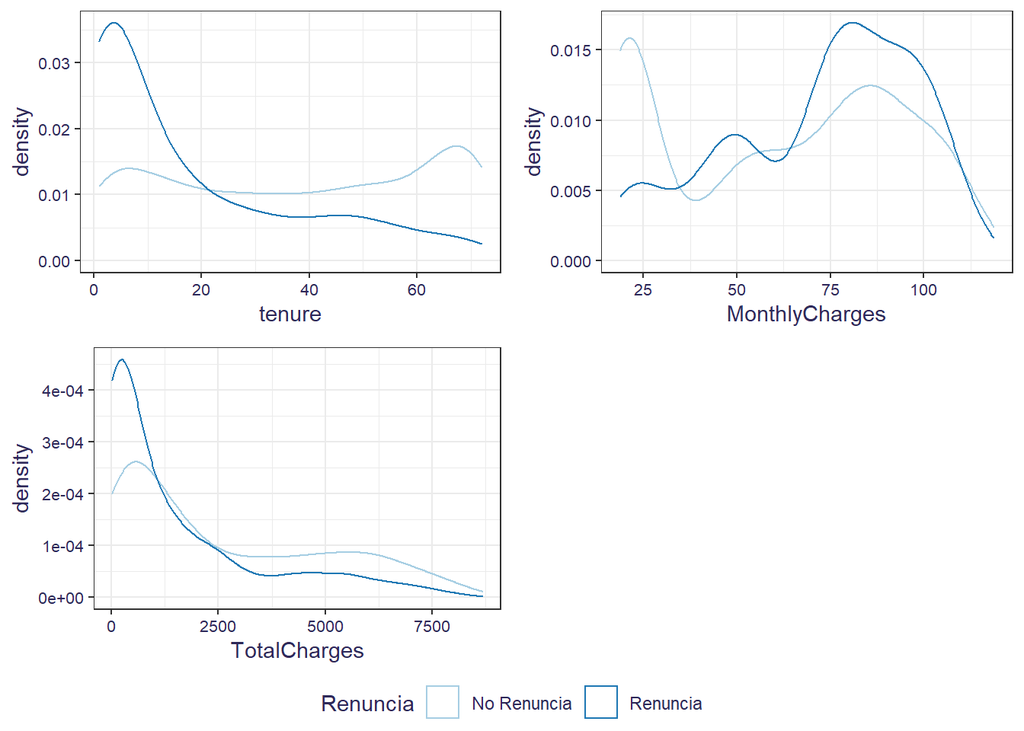

```r
plot1 <- ggplot(data = training_set_shapiro, aes(x = tenure)) +
         geom_density(aes(colour = Renuncia)) + theme_bw() +
  theme(plot.title = element_text(size=12, face = "bold.italic", color = "#2e2959"),
                          axis.text.y = element_text(size = 8, color = "#2e2959"),
                          axis.text.x = element_text(size = 8, color = "#2e2959"),
                          axis.title.x = element_text(color = "#2e2959"),
                          axis.title.y = element_text(color = "#2e2959"),
                          plot.caption = element_text(color = "#2e2959"),
                          legend.text = element_text(color = "#2e2959"),
                          legend.title = element_text(color = "#2e2959"),
                          plot.subtitle = element_text(color = "#2e2959")) +
  scale_color_brewer("Renuncia", palette = "Paired")
plot2 <- ggplot(data = training_set_shapiro, aes(x = MonthlyCharges)) +
         geom_density(aes(colour = Renuncia)) + theme_bw() +
  theme(plot.title = element_text(size=12, face = "bold.italic", color = "#2e2959"),
                          axis.text.y = element_text(size = 8, color = "#2e2959"),
                          axis.text.x = element_text(size = 8, color = "#2e2959"),
                          axis.title.x = element_text(color = "#2e2959"),
                          axis.title.y = element_text(color = "#2e2959"),
                          plot.caption = element_text(color = "#2e2959"),
                          legend.text = element_text(color = "#2e2959"),
                          legend.title = element_text(color = "#2e2959"),
                          plot.subtitle = element_text(color = "#2e2959")) +
  scale_color_brewer("Renuncia", palette = "Paired")
plot3 <- ggplot(data = training_set_shapiro, aes(x = TotalCharges)) +
         geom_density(aes(colour = Renuncia)) + theme_bw() +
  theme(plot.title = element_text(size=12, face = "bold.italic", color = "#2e2959"),
                          axis.text.y = element_text(size = 8, color = "#2e2959"),
                          axis.text.x = element_text(size = 8, color = "#2e2959"),
                          axis.title.x = element_text(color = "#2e2959"),
                          axis.title.y = element_text(color = "#2e2959"),
                          plot.caption = element_text(color = "#2e2959"),
                          legend.text = element_text(color = "#2e2959"),
                          legend.title = element_text(color = "#2e2959"),
                          plot.subtitle = element_text(color = "#2e2959")) +
  scale_color_brewer("Renuncia", palette = "Paired")

ggarrange(plot1, plot2, plot3, common.legend = TRUE, legend = "bottom")
```

## Supuestos

### Normalidad

Se realiza el **contraste de normalidad** Shapiro-Wilk para cada variable, según la categoría de abandono

```r
library(reshape2)
library(knitr)
library(dplyr)
datos_tidy <- melt(training_set_shapiro, value.name = "valor")
kable(datos_tidy %>% group_by(Renuncia, variable) %>% summarise(p_value_Shapiro.test = round(shapiro.test(valor)$p.value,10)))
```

| Renuncia | variable | p_value_Shapiro.test |
| --- | --- | --- |
| No Renuncia | tenure | 0 |
| No Renuncia | MonthlyCharges | 0 |
| No Renuncia | TotalCharges | 0 |
| Renuncia | tenure | 0 |
| Renuncia | MonthlyCharges | 0 |
| Renuncia | TotalCharges | 0 |

Se verifica en todos los casos un **p-value < 0.05**.

### Homogeneidad de varianzas

Se procede a verificar la **homogeneidad de varianzas** mediante el test de Bartlett.

```r
options(scipen = 999)

bartlett.test(training_set_shapiro$tenure~training_set_shapiro$Renuncia)
```

```
##
##  Bartlett test of homogeneity of variances
##
## data:  training_set_shapiro$tenure by training_set_shapiro$Renuncia
## Bartlett's K-squared = 19.146, df = 1, p-value = 0.00001211
```

```r
bartlett.test(training_set_shapiro$MonthlyCharges~training_set_shapiro$Renuncia)
```

```
##
##  Bartlett test of homogeneity of variances
##
## data:  training_set_shapiro$MonthlyCharges by training_set_shapiro$Renuncia
## Bartlett's K-squared = 25.619, df = 1, p-value = 0.000000416
```

```r
bartlett.test(training_set_shapiro$TotalCharges~training_set_shapiro$Renuncia)
```

```
##
##  Bartlett test of homogeneity of variances
##
## data:  training_set_shapiro$TotalCharges by training_set_shapiro$Renuncia
## Bartlett's K-squared = 25.418, df = 1, p-value = 0.0000004616
```

Se observa que en todos los casos el **p-value < 0,05**, por lo que se rechaza la H0 que afirma igualdad de varianzas.

### Test M de Box

La hipótesis nula para esta prueba es que las matrices de covarianza observadas para las variables dependientes son iguales en todos los grupos. En otras palabras, un resultado de prueba no significativo (es decir, uno con un valor p grande) indica que las matrices de covarianza son iguales. La estadística de prueba generada se llama estadística M de Box.

Esta prueba informará un resultado estadísticamente significativo cuando en realidad no exista uno.

```r
library(biotools)
boxM(data=training_set_shapiro[, 1:3], group=training_set_shapiro$Renuncia)
```

```
##
##  Box's M-test for Homogeneity of Covariance Matrices
##
## data:  training_set_shapiro[, 1:3]
## Chi-Sq (approx.) = 374.73, df = 6, p-value < 0.00000000000000022
```

*Se rechaza la H0*.

## Modelo

El primer resultado es un *modelo discriminante lineal* que puede predecir qué personas se irían usando las variables independientes. Después de hacer este modelo, se calcula la relación de clasificación correcta.

```r
#linear discrimanant model
lda1 <- lda(formula = Churn ~ tenure + MonthlyCharges + TotalCharges, data= training_set)

#training (0,78)
predicted_lda1_train <- predict(lda1, newdata = training_set)
table(training_set$Churn, predicted_lda1_train$class)
```

```
##
##         No  Yes
##   No  3963  473
##   Yes  858  738
```

```r
cat("Accuracy training: ",sum(diag(as.matrix(table(training_set$Churn, predicted_lda1_train$class)))) / sum(sum(as.matrix(table(training_set$Churn, predicted_lda1_train$class)))))
```

```
## Accuracy training:  0.7793435
```

```r
#test (0,78)
predicted_lda1 <- predict(lda1, newdata = test_set)
table(test_set$Churn, predicted_lda1$class)
```

```
##
##        No Yes
##   No  636  91
##   Yes 133 140
```

```r
cat("Accuracy testing: ",sum(diag(as.matrix(table(test_set$Churn, predicted_lda1$class)))) / sum(sum(as.matrix(table(test_set$Churn, predicted_lda1$class)))))
```

```
## Accuracy testing:  0.776
```

Salida del modelo de discriminante lineal:

```r
lda1
```

```
## Call:
## lda(Churn ~ tenure + MonthlyCharges + TotalCharges, data = training_set)
##
## Prior probabilities of groups:
##        No       Yes
## 0.7354111 0.2645889
##
## Group means:
##       tenure MonthlyCharges TotalCharges
## No  37.98873       61.36540     2577.293
## Yes 18.04950       74.24721     1538.819
##
## Coefficients of linear discriminants:
##                          LD1
## tenure         -0.0161921776
## MonthlyCharges  0.0379090498
## TotalCharges   -0.0003956721
```

Se dibujan las áreas que se delimitan para cada una de las variables:

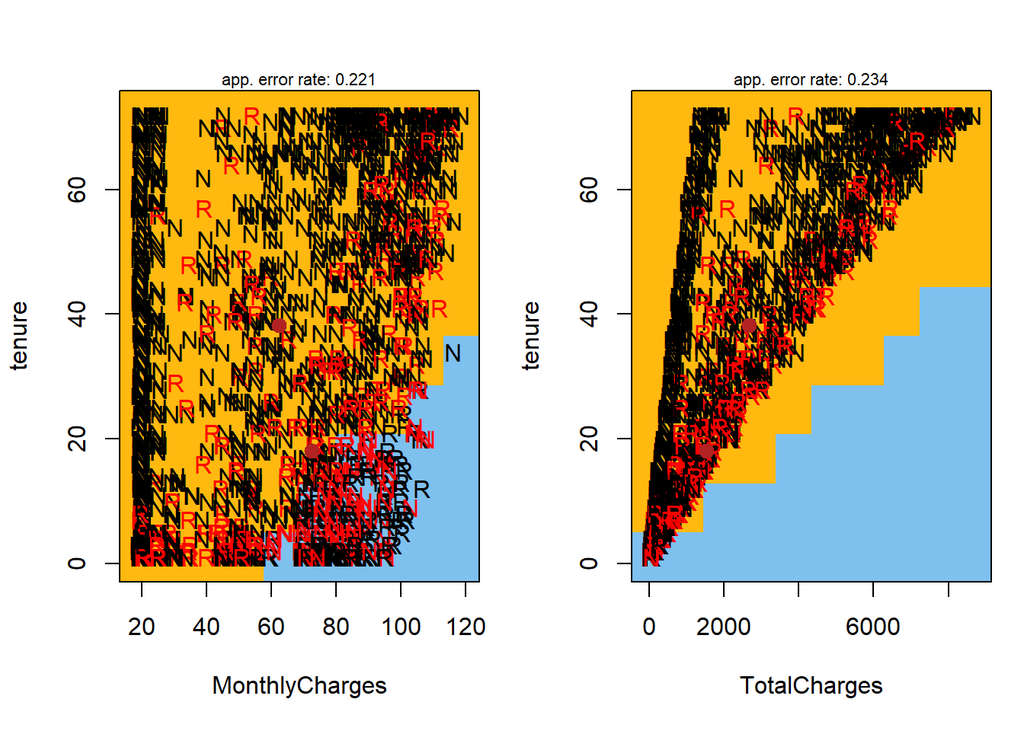

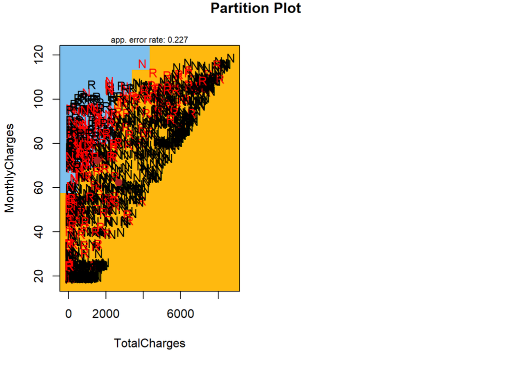

```r
library(klaR)
partimat(Renuncia ~ tenure + MonthlyCharges + TotalCharges,
         data= training_set_shapiro, method = "lda", prec = 10,
         image.colors = c("darkgoldenrod1", "skyblue2"),
         col.mean = "firebrick")
```

### Comparación de modelo lineal y modelo no lineal

El modelo discriminante lineal muestra aproximadamente un 78% de precisión. El siguiente modelo es el *modelo discriminatorio no lineal*.

```r
#nonliner discrimanant model
qda1 <-  qda(formula = Churn ~ tenure + MonthlyCharges + TotalCharges, data= training_set)

#trainign (74%)
predicted_qda1_train <- predict(qda1, newdata = training_set)
table(training_set$Churn, predicted_qda1_train$class)
```

```
##
##         No  Yes
##   No  3455  981
##   Yes  563 1033
```

```r
cat("Accuracy training: ",sum(diag(as.matrix(table(training_set$Churn, predicted_qda1_train$class)))) / sum(sum(as.matrix(table(training_set$Churn, predicted_qda1_train$class)))))
```

```
## Accuracy training:  0.7440318
```

```r
#test (72%)
predicted_qda1 <-  predict(qda1, newdata = test_set)
table(test_set$Churn, predicted_qda1$class)
```

```
##
##        No Yes
##   No  541 186
##   Yes  93 180
```

```r
#the ratio of correct ratio of correct classification.
cat("Accuracy training: ",sum(diag(as.matrix(table(test_set$Churn, predicted_qda1$class)))) / sum(sum(as.matrix(table(test_set$Churn, predicted_qda1$class)))))
```

```
## Accuracy training:  0.721
```

Salida del modelo de discriminante no lineal:

```r
qda1
```

```
## Call:
## qda(Churn ~ tenure + MonthlyCharges + TotalCharges, data = training_set)
##
## Prior probabilities of groups:
##        No       Yes
## 0.7354111 0.2645889
##
## Group means:
##       tenure MonthlyCharges TotalCharges
## No  37.98873       61.36540     2577.293
## Yes 18.04950       74.24721     1538.819
```

Se dibujan las áreas que se delimitan para cada una de las variables:

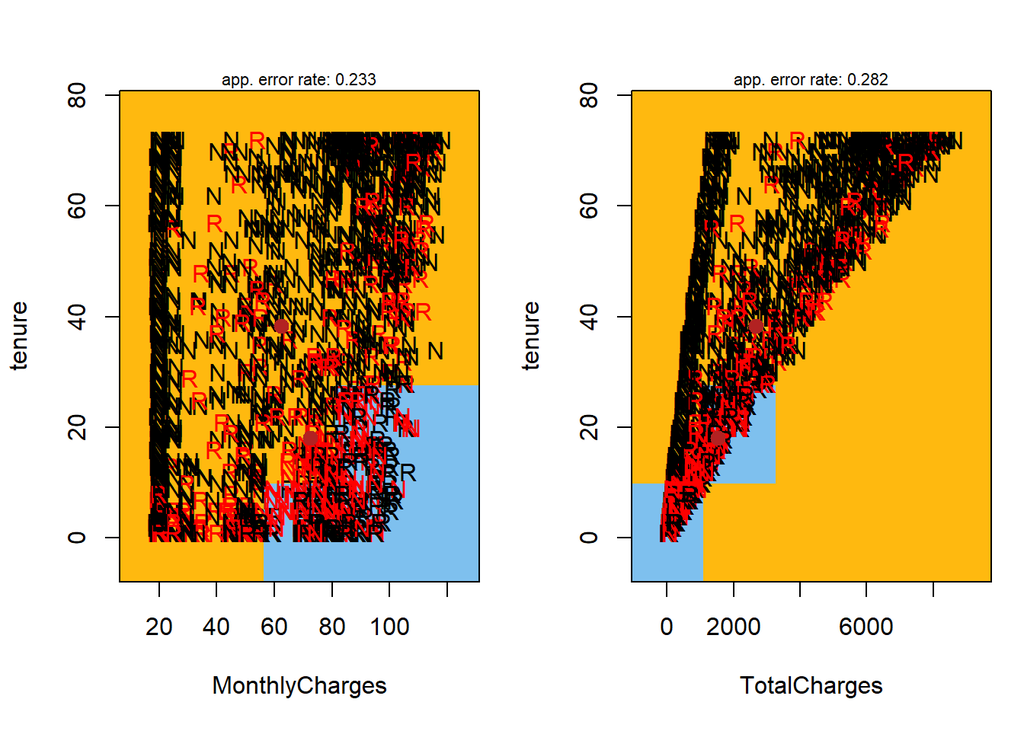

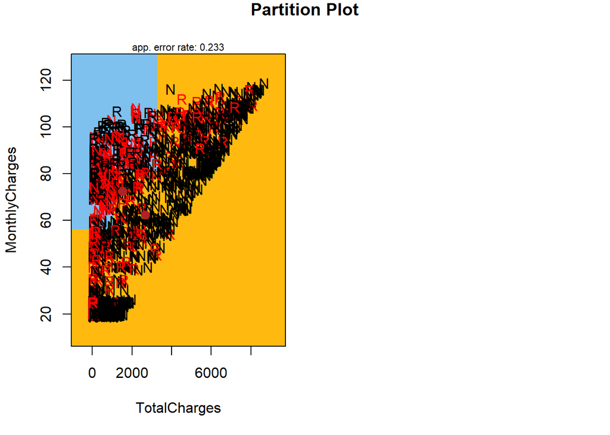

```r
partimat(formula = Renuncia ~ tenure + MonthlyCharges + TotalCharges,
         data= training_set_shapiro,
         method = "qda", prec = 5,
         image.colors = c("darkgoldenrod1", "skyblue2"),
         col.mean = "firebrick")
```

El *modelo discriminante no lineal muestra aproximadamente el 72% de precisión*. **Es mejor la predicción del modelo discriminante lineal**.

### CURVA ROC

Por último, se analiza la comparación de modelos mediante una curva ROC para cada modelo.

```r
#ROC curve
#linear discrimininant
par(mfrow = c(2,1))
lda1_p <- predict(lda1, newdata = test_set, type = "response")
lda1_pr <- prediction(as.numeric(lda1_p$class), test_set$Churn)
lda1_prf <- performance(lda1_pr, measure = "tpr", x.measure = "fpr")
plot(lda1_prf, main = 'ROC curve of linear discriminant model')

lda1_auc <- performance(lda1_pr, measure = "auc")
lda1_auc <- lda1_auc@y.values
cat("AUC Discriminante Lineal: ",round(as.numeric(lda1_auc), digits = 4))
```

```
## AUC Discriminante Lineal:  0.6938
```

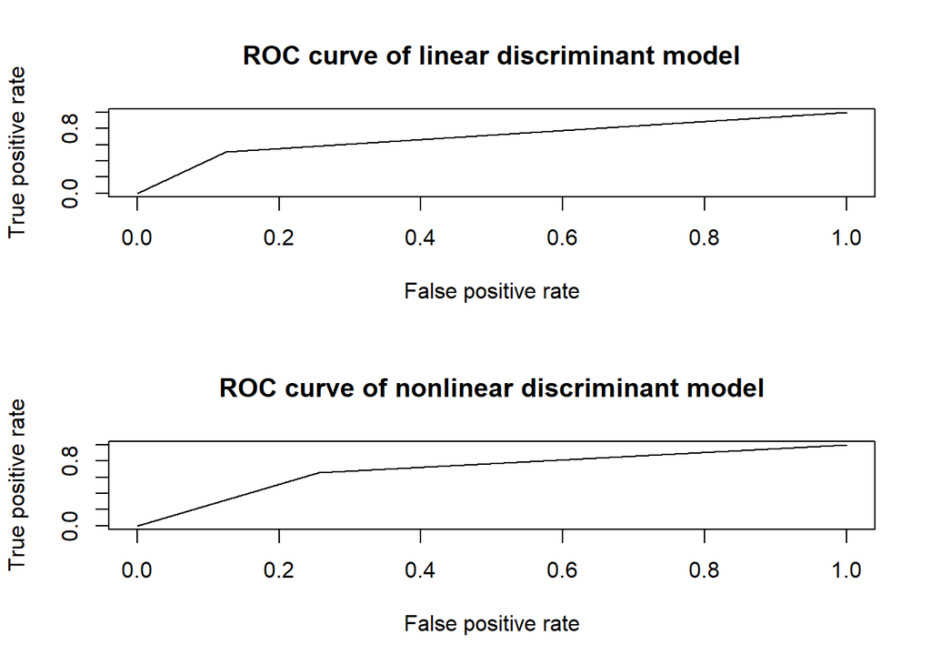

```r
#nonlinear discriminant model
qda1_p <- predict(qda1, newdata = test_set, type = "response")
qda1_pr <- prediction(as.numeric(qda1_p$class), test_set$Churn)
qda1_prf <- performance(qda1_pr, measure = "tpr", x.measure = "fpr")
plot(qda1_prf, main = 'ROC curve of nonlinear discriminant model')
```

```r
qda1_auc <- performance(qda1_pr, measure = "auc")
qda1_auc <- qda1_auc@y.values
cat("Discriminante no lineal: ",round(as.numeric(qda1_auc), digits = 4))
```

```
## Discriminante no lineal:  0.7017
```

## Resultado de comparación

Desde la curva ROC y AUC (Área bajo la curva), el AUC de los modelos es similar (Lineal = 0.69; No lineal = 0.70) lo que indica que el modelo es aceptable.

## Predicción de nuevos clientes

Finalmente, se prueba realizar una estimación para un nuevo cliente para saber si va a abandonar los servicios o no.

### Prueba 1

```r
nuevas_observaciones <- data.frame(tenure = 10, MonthlyCharges = 57, TotalCharges = 1800)

predict(object = lda1, newdata = nuevas_observaciones)
```

```
## $class
## [1] No
## Levels: No Yes
##
## $posterior
##         No      Yes
## 1 0.739147 0.260853
##
## $x
##         LD1
## 1 0.2719118
```

### Prueba 2

```r
nuevas_observaciones <- data.frame(tenure = 50, MonthlyCharges = 127, TotalCharges = 2800)

predict(object = lda1, newdata = nuevas_observaciones)
```

```
## $class
## [1] Yes
## Levels: No Yes
##
## $posterior
##          No       Yes
## 1 0.2836631 0.7163369
##
## $x
##        LD1
## 1 1.882186
```